# Forecasting Project

Hewson

April 10, 2022

### Introduction

In this paper, we will examine several potential indicators of inflation in the US.

Using data from FRED, this paper will observe how factors ranging from consumption, unemployment, and manufacturing can influence inflation in the US.

```r
require(fpp3)
require(tidyverse)
require(dplyr)
require(tidyquant)
require(lubridate)
require(timetk)
require(kableExtra)
require(reshape)
```

### Variables and Data

The variables used in this model are Personal Consumption Expenditures: Chain-type Price Index, Unemployment Rate, 1-Year Expected Inflation, Capacity Utilization: Total Index, and Industrial Production: Manufacturing (NAICS).

```r
varList <- c("PCEPI", "UNRATE", "EXPINF1YR", "TCU", "IPMAN")
X <-
  tq_get(varList, get = "economic.data", from = "1991-01-01") %>%
  mutate(Month = yearmonth(date), value = price) %>%
  dplyr::select(-c(date, price)) %>%
  as_tsibble(index = Month, key = symbol)

Xw <- X %>%
  pivot_wider(names_from = symbol, values_from = value) %>%
  as_tsibble()
```

These variables were selected for a varity of factors. Consumption expenditures (PCEPI) were chosen as they can provide insight into spending habits. When more spending would lead to higher prices, and model some level of price inflation. Should prices increase on one good, consumers ought to switch to substitute product.

The unemployment rate (UNRATE) is used as it is often an inverse of inflation, at least by traditional FED standards. Balancing unemployment with inflation, or at the very least keeping these at a reasonable level, is the key to economic growth.

“Capacity Utilization: Total Industry (TCU) is the percentage of resources used by corporations and factories to produce goods in manufacturing, mining, and electric and gas utilities for all facilities located in the United States (excluding those in U.S. territories).”[1] In other words, this measures how corporations use certain resources in their manufacturing. Should input costs increase, this percentage ought to either decrease to offset these costs, or stay at prior levels but with a higher price to offset the new input price, thus inducing inflation.

Industrial Production: Manufacturing (IPMAN) is a similar measure to TCU, however this measures the real change in industrial manufacturing. Like TCU, a change in this will be an indicator of a change in inputs, thus raising prices.

With the 1-Year Expected Inflation measure, this will track people’s perception of future inflation, which in many cases can induce inflation. If a product is predicted to be difficult to obtain in the near future due to inflation, people will buy the product now, thus decreasing the quantity supplied and increasing the price. This has been seen in the used car market over the past two years.

With these models in tow, we can begin the modeling process.

```r
Z <- Xw %>% select(c(EXPINF1YR, IPMAN, PCEPI, TCU, UNRATE)) %>%
  mutate(infl = 1200*log(PCEPI/lag(PCEPI))) %>%
  mutate(dinfl = infl - lag(infl,1)) %>%
  mutate(dinfl12 = 100*log(PCEPI/lag(PCEPI,12)) - lag(infl,12)) %>%
  mutate(unrate = UNRATE - lag(UNRATE)) %>%
  mutate(tcu = TCU - lag(TCU)) %>%
  mutate(ipman = 1200*log(IPMAN/lag(IPMAN))) %>%
  mutate(expinf1yr = EXPINF1YR - lag(EXPINF1YR)) %>%
  select(-c(PCEPI, UNRATE, TCU, IPMAN, EXPINF1YR)) %>%
  drop_na()
train_data <- Z %>% filter_index(~ "2019-12")
test_data <- Z %>% filter_index("2020-01" ~ .)

Z_long <- Z %>%
  pivot_longer(!Month, names_to = "Category", values_to = "value2")
```

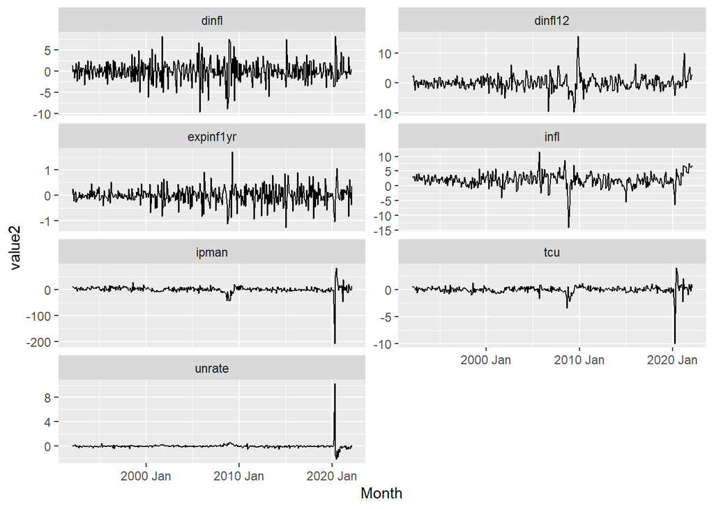

```r
Zm <- melt(Z_long, id=c("Category", "value2")) %>%
  mutate(Month = value) %>%
  select(-c(variable, value))

Zm %>% ggplot(aes(x = Month, y = value2)) +
  geom_line() +
  facet_wrap(~ Category, scales = "free_y", ncol = 2)
```

### Modeling

This model will use the base monthly Philip’s Curve model as defined by Stock and Watson (1999), shown here:
$$\pi_{t}^{12} - \pi_{t-12} = \theta + \beta(B)\Delta\pi_{t-12} + \gamma(B)u_{t-12} + \epsilon_{t}$$

```r
fitALL <- train_data %>%
  model(
    mPC = TSLM(dinfl12 ~ 1 +
                 lag(dinfl,12) + lag(dinfl,13) + lag(dinfl,14) +
                 lag(dinfl,15) + lag(dinfl,16) + lag(dinfl,17) +
                 lag(dinfl,18) + lag(dinfl,19) + lag(dinfl,20) +
                 lag(dinfl,21) + lag(dinfl,22) + lag(dinfl,23) +
                 lag(unrate,12) + lag(unrate,13) + lag(unrate,14) +
                 lag(unrate,15) + lag(unrate,16) + lag(unrate,17) +
                 lag(unrate,18) + lag(unrate,19) + lag(unrate,20) +
                 lag(unrate,21) + lag(unrate,22) + lag(unrate,23)
                 ),
    mTCU = TSLM(dinfl12 ~ 1 +
                 lag(dinfl,12) + lag(dinfl,13) + lag(dinfl,14) +
                 lag(dinfl,15) + lag(dinfl,16) + lag(dinfl,17) +
                 lag(dinfl,18) + lag(dinfl,19) + lag(dinfl,20) +
                 lag(dinfl,21) + lag(dinfl,22) + lag(dinfl,23) +
                 lag(tcu,12) + lag(tcu,13) + lag(tcu,14) +
                 lag(tcu,15) + lag(tcu,16) + lag(tcu,17) +
                 lag(tcu,18) + lag(tcu,19) + lag(tcu,20) +
                 lag(tcu,21) + lag(tcu,22) + lag(tcu,23)
                 ),
    mIP = TSLM(dinfl12 ~ 1 +
                 lag(dinfl,12) + lag(dinfl,13) + lag(dinfl,14) +
                 lag(dinfl,15) + lag(dinfl,16) + lag(dinfl,17) +
                 lag(dinfl,18) + lag(dinfl,19) + lag(dinfl,20) +
                 lag(dinfl,21) + lag(dinfl,22) + lag(dinfl,23) +
                 lag(ipman,12) + lag(ipman,13) + lag(ipman,14) +
                 lag(ipman,15) + lag(ipman,16) + lag(ipman,17) +
                 lag(ipman,18) + lag(ipman,19) + lag(ipman,20) +
                 lag(ipman,21) + lag(ipman,22) + lag(ipman,23)
                 ),
    mEXP_INF = TSLM(dinfl12 ~ 1 +
                 lag(dinfl,12) + lag(dinfl,13) + lag(dinfl,14) +
                 lag(dinfl,15) + lag(dinfl,16) + lag(dinfl,17) +
                 lag(dinfl,18) + lag(dinfl,19) + lag(dinfl,20) +
                 lag(dinfl,21) + lag(dinfl,22) + lag(dinfl,23) +
              lag(expinf1yr,12) + lag(expinf1yr,13) + lag(expinf1yr,14) +
              lag(expinf1yr,15) + lag(expinf1yr,16) + lag(expinf1yr,17) +
              lag(expinf1yr,18) + lag(expinf1yr,19) + lag(expinf1yr,20) +
              lag(expinf1yr,21) + lag(expinf1yr,22) + lag(expinf1yr,23)
                 )
  )
tidy(fitALL)
```

| .model | term | estimate | std.error | statistic | p.value |
| --- | --- | --- | --- | --- | --- |
| mPC | (Intercept) | -0.004885051 | 0.067489918 | -0.07238194 | 9.423484e-01 |
| mPC | lag(dinfl, 12) | -0.848924126 | 0.032763117 | -25.91096936 | 4.024947e-77 |
| mPC | lag(dinfl, 13) | -0.840027264 | 0.036635999 | -22.92901238 | 7.841827e-67 |
| mPC | lag(dinfl, 14) | -0.789750971 | 0.041023243 | -19.25130543 | 1.328353e-53 |
| mPC | lag(dinfl, 15) | -0.738019899 | 0.044646539 | -16.53028242 | 1.381005e-43 |
| mPC | lag(dinfl, 16) | -0.688907948 | 0.046057484 | -14.95756808 | 8.524718e-38 |
| mPC | lag(dinfl, 17) | -0.610136472 | 0.047731800 | -12.78259914 | 6.391396e-30 |
| mPC | lag(dinfl, 18) | -0.551722019 | 0.048413747 | -11.39597854 | 4.558464e-25 |
| mPC | lag(dinfl, 19) | -0.457184907 | 0.047897017 | -9.54516448 | 6.235238e-19 |
| mPC | lag(dinfl, 20) | -0.355476373 | 0.046820445 | -7.59233214 | 4.437996e-13 |

[output cut: 90 more lines]

This chart indicates the marginal impact of each variable on future inflation. The model also accounts for the aforementioned variables, placing them into their own submodel.

### Model Accuracy Part 1

To verify if these models hold any weight, an accuracy check is run.

```r
accuracy(fitALL)
```

| .model | .type | ME | RMSE | MAE | MPE | MAPE | MASE | RMSSE | ACF1 |
| --- | --- | --- | --- | --- | --- | --- | --- | --- | --- |
| mPC | Training | -1.048983e-17 | 1.131477 | 0.8234824 | 39.14484 | 149.2423 | 0.3267277 | 0.3142035 | 0.8608875 |
| mTCU | Training | -2.373743e-17 | 1.067781 | 0.7982043 | 31.02249 | 152.2639 | 0.3166983 | 0.2965155 | 0.8598229 |
| mIP | Training | -3.220602e-17 | 1.066216 | 0.8117628 | 44.79635 | 168.1101 | 0.3220778 | 0.2960808 | 0.8640820 |
| mEXP_INF | Training | 4.087990e-17 | 1.144800 | 0.8341910 | 45.19122 | 146.6636 | 0.3309765 | 0.3179031 | 0.8808479 |

This chart demonstrates that these models are all relatively the same based on the RSME, with no model significantly outperforming the other. In other words, none of these models alone are great indicators of future inflation. For sake of completion, we can zoom in on one model to verify its accuracy.

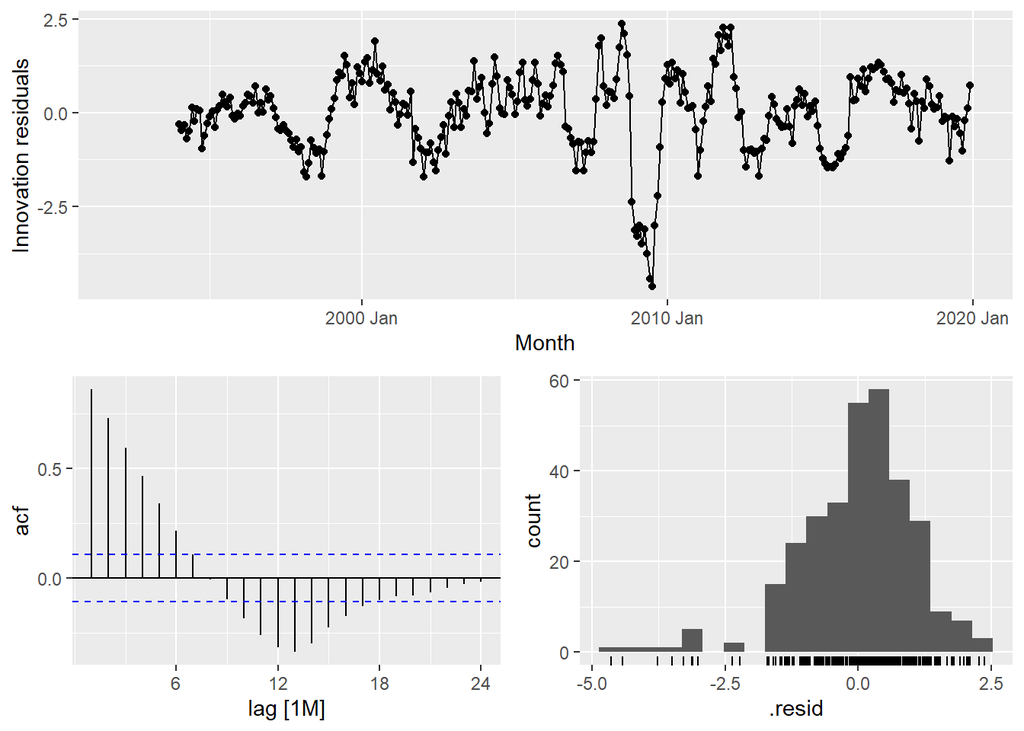

```r
fitALL %>% select(mTCU) %>% gg_tsresiduals()
```

TCU appears to have significant serial correlation in the early periods, and features many outliers in its residual, therefore dragging down its ability to accurately predict inflation. There also seems to be considerable seasonality in the data, which may be why this model is not great.

### The Combined Model

For one final examination of this model’s efficacy, let’s take an average of the models.

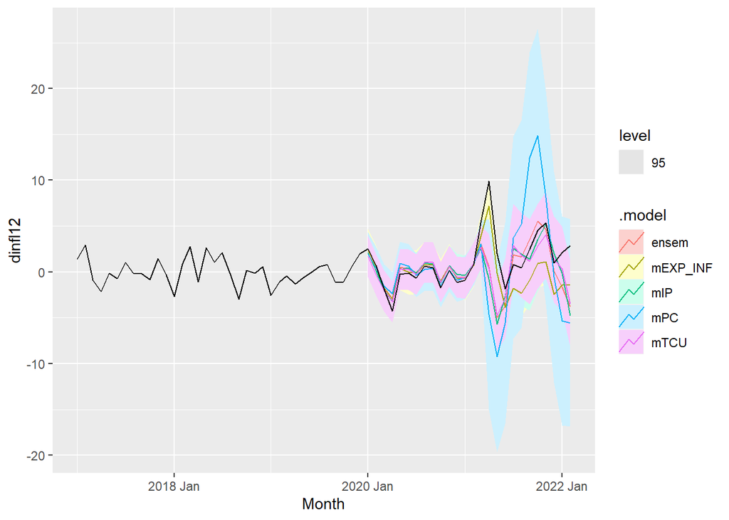

```r
fit_combo_all <- fitALL %>%
  mutate(ensem = (mPC + mTCU + mIP + mEXP_INF)/4)
fc_combo_all <- fit_combo_all %>% forecast(new_data = test_data)

fc_combo_all %>% autoplot(filter(Z, year(Month) > 2016), level = c(95))
```

This chart shows how these models are underestimating inflation, with the solid black line being actual inflation. Additionally, the shaded confidence intervals demonstrate just how off the models could be.

### Model Accuracy Part 2

Running an accuracy test over this amalgamation produces the following results.

```r
accuracy(fit_combo_all)
```

| .model | .type | ME | RMSE | MAE | MPE | MAPE | MASE | RMSSE | ACF1 |
| --- | --- | --- | --- | --- | --- | --- | --- | --- | --- |
| mPC | Training | -1.048983e-17 | 1.131477 | 0.8234824 | 39.14484 | 149.2423 | 0.3267277 | 0.3142035 | 0.8608875 |
| mTCU | Training | -2.373743e-17 | 1.067781 | 0.7982043 | 31.02249 | 152.2639 | 0.3166983 | 0.2965155 | 0.8598229 |
| mIP | Training | -3.220602e-17 | 1.066216 | 0.8117628 | 44.79635 | 168.1101 | 0.3220778 | 0.2960808 | 0.8640820 |
| mEXP_INF | Training | 4.087990e-17 | 1.144800 | 0.8341910 | 45.19122 | 146.6636 | 0.3309765 | 0.3179031 | 0.8808479 |
| ensem | Training | -2.883882e-17 | 1.067286 | 0.7917778 | 40.03873 | 149.4136 | 0.3141485 | 0.2963782 | 0.8739339 |

```r
accuracy(fc_combo_all, test_data)
```

| .model | .type | ME | RMSE | MAE | MPE | MAPE | MASE | RMSSE | ACF1 |
| --- | --- | --- | --- | --- | --- | --- | --- | --- | --- |
| ensem | Test | 0.9299861 | 2.870740 | 1.661498 | 40.69235 | 114.6611 | NaN | NaN | 0.6064240 |
| mEXP_INF | Test | 1.2139813 | 2.164782 | 1.612792 | 79.96400 | 126.4675 | NaN | NaN | 0.8853447 |
| mIP | Test | 0.9654823 | 3.154241 | 1.742198 | 31.23113 | 128.3162 | NaN | NaN | 0.5112448 |
| mPC | Test | 0.5631677 | 5.331202 | 3.336513 | 27.86433 | 206.8889 | NaN | NaN | 0.6742395 |
| mTCU | Test | 0.9773131 | 2.812567 | 1.676293 | 23.70996 | 118.6419 | NaN | NaN | 0.5223683 |

Again, these models aren’t great. However, based on the RMSE indicator, the model using Expected Inflation performed the best. Using this metric, a lower score indicates a better model. Considering these models are all fairly similar to each other, it would be best to use different variables to model inflation in the US.

[1] - https://fred.stlouisfed.org/series/TCU